# MA Survey Report: Paper 02 When Active Learning Backfires: Differential Effects of Student-Centered Teaching on Evaluation and Learning Anxiety via Domain-Specific Engagement

Cheng Peng & Laura Pyatt

West Chester University

# 1 Introduction

Student-centered teaching has become a cornerstone of contemporary mathematics education reform. Inquiry-based learning, collaborative problem-solving, and peer discussion are widely promoted as strategies that position students as active investigators rather than passive recipients of knowledge (Tang, 2025). Meta-analytic evidence supports these approaches for improving cognitive outcomes: Freeman et al. (2014) demonstrated that active learning substantially increases examination performance and reduces failure rates in STEM disciplines compared to traditional lecturing.

A parallel literature suggests that student-centered pedagogy may carry hidden emotional costs. By requiring students to present solutions publicly, explain reasoning aloud, and collaborate openly, these methods inherently increase performance demands and social exposure (Cooper et al., 2018). Recent empirical work has begun to document this tension. Studies of undergraduate STEM classrooms have found that active learning environments can increase anxiety, particularly among students who fear negative evaluation from peers and instructors (Cooper et al., 2018; England et al., 2017). This raises a critical question: Does student-centered teaching simultaneously help and harm different dimensions of math anxiety?

Math anxiety is not a unitary construct. Factor-analytic studies consistently distinguish between Evaluation Anxiety (MEA) —fear of being scrutinized during public mathematical performance—and Learning Anxiety (LA) —cognitive tension experienced when grappling with unfamiliar concepts (Hopko et al., 2003; Caviola et al., 2017). These dimensions have distinct antecedents and consequences. EA is tied to social avoidance and classroom participation; LA is tied to cognitive load and conceptual understanding (Mesghina et al., 2024; Paechter et al., 2017). A pedagogical strategy that increases public engagement may therefore exacerbate one dimension while alleviating the other (Lanfaloni et al., 2023).

The present study tests this hypothesis through a parallel multiple mediation model with moderated mediation. We propose that student-centered teaching exerts differential effects on EA and LA through two functionally distinct engagement pathways:

- In-class Social Engagement (ISE) transmits social threat, predicting higher EA.
- After-class Behavioral Engagement (ABE) transmits mastery experiences, predicting lower MLA.

Self-efficacy is tested as a moderator that may buffer the ISE → EA pathway. Students with high self-efficacy may interpret public engagement as an opportunity rather than a threat (Bandura, 1997; Peng et al., 2024).

This investigation makes three contributions. First, it advances the learning avoidance model (Ashcraft & Krause, 2007; Mesghina et al., 2024) by specifying engagement as the mechanism through which pedagogical strategies exert differential effects on anxiety dimensions. Second, it challenges the assumption that student-centered pedagogy is uniformly beneficial by documenting its evaluative costs (Cooper et al., 2018). Third, it offers a practical instructional protocol that separates concept introduction from public assessment to maximize benefits while minimizing costs.

## 1.1 The Shift to Student-Centered Pedagogy

Modern mathematics education has moved decisively away from conventional, teacher-centered instruction toward dynamic, student-centered classrooms (Tang, 2025; Birgin & Uzun Yazici, 2026). This transformation emphasizes pedagogies that position students as active investigators, strategically integrate technology, and apply psychological principles of learning (Freeman et al., 2014). Student-centered approaches—including inquiry-based learning, collaborative problem-solving, and peer instruction—have demonstrated robust effects on conceptual understanding and problem-solving transfer (Boaler, 2015, 2020).

A systematic review of mathematics teaching strategies concluded that student-centered methods, problem-based approaches, creative and discovery approaches, inclusive instructional strategies, and inquiry-based learning are associated with reduced mathematics learning anxiety (Boaler, 2015, 2020; Ponce, 2025). This finding aligns with the theoretical rationale that active engagement with mathematical concepts builds competence and reduces the cognitive tension associated with unfamiliar material (Fredricks et al., 2004).

However, this literature has predominantly focused on learning anxiety while neglecting evaluation anxiety. The conflation of these dimensions may obscure the differential effects of pedagogy on distinct emotional experiences (Caviola et al., 2017; Hopko et al., 2003).

## 1.2 The Paradox of Active Learning

Despite documented cognitive benefits, student-centered pedagogy inherently increases public performance demands (Cooper et al., 2018). Students are asked to present solutions at the board, explain reasoning to peers, and collaborate in visible ways—activities that can trigger social-evaluative threat (England et al., 2017). This creates a paradox: the same pedagogy that builds mastery may also expose students to evaluative scrutiny.

Emerging evidence supports this concern. Cooper et al. (2018) found that fear of negative evaluation (FNE) was the primary factor driving anxiety in active learning science courses, with cold calling and random call producing exclusively negative emotional effects. Busch et al. (2023) similarly documented that first-generation students, LGBTQ+ students, and students with disabilities report disproportionately high FNE levels in active learning environments. These findings suggest that active learning may create emotional costs that offset cognitive gains for certain student populations (Downing et al., 2020).

## 1.3 Distinguishing Evaluation Anxiety and Learning Anxiety

The multidimensional nature of math anxiety is well established (Wigfield & Meece, 1988; Ho et al., 2000). Factor analyses consistently support a distinction between evaluation anxiety (fear of public performance and scrutiny) and learning anxiety (cognitive tension during concept acquisition) (Hopko et al., 2003; Caviola et al., 2017). The Abbreviated Math Anxiety Scale (AMAS; Hopko et al., 2003) operationalizes this distinction through the Learning Math Anxiety (LMA) and Math Evaluation Anxiety (MEA) subscales, with demonstrated reliability across diverse populations (Caviola et al., 2017; Ikeda et al., 2025; Carey et al., 2017).

These dimensions demonstrate divergent relationships with achievement. Lanfaloni et al. (2023) found that students who improved from inadequate to sufficient mathematics performance reported significantly lower Learning Math Anxiety, while Evaluation Anxiety showed no significant difference between improvers and non-improvers. Namkung et al. (2025) similarly reported that mathematics vocabulary and computational fluency mediate the anxiety-achievement relation differently for students with and without learning difficulties. This dissociation suggests that LA is more closely tied to learning processes, while EA is more closely tied to performance contexts (Paechter et al., 2017).

Critically, the same pedagogical strategy may affect these dimensions in opposite directions. A student-centered activity that reduces uncertainty about concepts (lowering LA) may simultaneously increase public exposure (raising EA) (Cooper et al., 2018; Ponce, 2025).

## 1.4 Engagement as the Mechanism

Engagement is the behavioral manifestation of motivation and a robust proximal predictor of academic achievement (Fredricks et al., 2004; Wang et al., 2016). Wang et al. (2016) distinguished between in-class social engagement (participation, asking questions, collaboration) and after-class behavioral engagement (homework completion, practice). These engagement types serve different psychological functions (Fredricks et al., 2004; Skinner et al., 2009).

**In-class social engagement (ISE)** involves visible participation that exposes students to peer evaluation. It transmits social threat, making it theoretically relevant to Evaluation Anxiety (Cooper et al., 2018; England et al., 2017). **After-class behavioral engagement (ABE)** involves independent practice that builds competence. It transmits mastery experiences, making it theoretically relevant to Learning Anxiety (Mesghina et al., 2024; Wang et al., 2016).

This functional dissociation is central to our theoretical model. Student-centered teaching may increase both ISE and ABE, but these increases carry opposite emotional consequences (Abu-Hilal & Al Abed, 2019).

## 1.5 The Moderating Role of Self-Efficacy

Self-efficacy shapes how students interpret engagement demands (Bandura, 1997). Students with high math self-efficacy view public engagement as an opportunity for mastery demonstration rather than a threat (Peng et al., 2024). Research supports this buffering role. Peng et al. (2024) found that math anxiety moderated the reciprocal relations between self-efficacy and achievement: higher anxiety attenuated the positive association of self-efficacy on achievement, while lower anxiety amplified it. This suggests that self-efficacy and anxiety interact dynamically, with self-efficacy potentially protecting against evaluative threat (Abu-Hilal & Al Abed, 2019; Bandura, 1997).

## 1.6 Hypotheses

Given the limited prior work integrating instructional style with discrete anxiety pathways, the present hypotheses are exploratory in nature. Rather than testing a fully specified causal model, we forward a set of provisional predictions concerning how student-centered and teacher-centered teaching may differentially shape evaluation anxiety (EA) and learning anxiety (LA) through distinct engagement channels. These hypotheses are intended to map plausible pathways and generate testable expectations for subsequent confirmatory work, not to assert definitive causal claims.

**H1a**: Student-centered teaching positively predicts Evaluation Anxiety via increased In-class Social Engagement (the “spotlight effect”).

**H1b**: Student-centered teaching negatively predicts Learning Anxiety via increased After-class Behavioral Engagement (mastery experiences).

**H2**: Self-efficacy moderates the ISE → EA path, such that the positive effect is weaker for high-efficacy students.

**H3**: Teacher-centered teaching shows opposite patterns: negatively predicting EA via reduced ISE, but positively predicting LA via reduced ABE.

# 2 Methods

## 2.1 Measures

**Math Anxiety (EA and LA)**. Math anxiety was measured using the Abbreviated Math Anxiety Scale (AMAS; Hopko et al., 2003), a 9-item instrument comprising two dimensions: Evaluation Anxiety (4 items) and Learning Anxiety (5 items). The AMAS has demonstrated strong reliability and validity across diverse samples (Carey et al., 2017; Caviola et al., 2017; Ikeda et al., 2025).

**Self-Efficacy**. Students’ self-reported belief in their capability in mathematics was measured using a standardized 3-item instrument (Bandura, 1997).

**Engagement**. Engagement was assessed using the In-class Social Engagement and After-class Behavioral Engagement subscales of the Math and Science Engagement Scale (Wang et al., 2016), each rated on a 5-point Likert scale.

**Table 1**

*Survey Instruments Used to Measure Math Anxiety, Teaching Strategies, Engagement, and Self-Efficacy*

[output not shown]

## 2.2 Analytical Strategy

To examine the relationships among perceived teaching strategies, student engagement, and math anxiety, a parallel multiple mediation analysis was conducted. The conceptual model, presented in Figure 1, specifies perceived teaching (both student-centered and teacher-centered) as the predictor variables (IV), in-class social engagement (ISE) and after-class behavioral engagement (ABE) as parallel mediators (M), and evaluation anxiety (MEA) and learning anxiety (MLA) as the outcome variables (DV). The model includes eight parallel indirect paths (a₁b₁ through a₄b₄) to test the mediating effects of engagement, alongside direct paths (c₁′ through c₄′) from the predictors to the outcomes. Additionally, self-efficacy was tested as a moderator of the relationships between engagement and math anxiety.

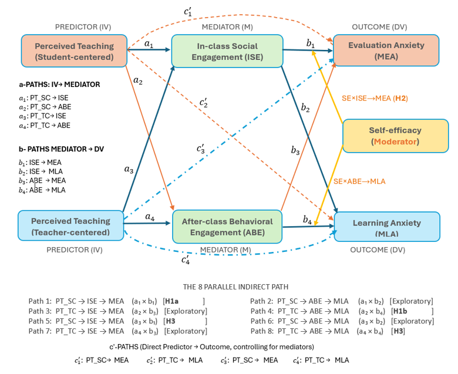

```r
include_graphics("ConceptualModel.png")
```

**Figure 1**. Conceptual parallel multiple mediation model depicting the relationships among perceived teaching strategies (student-centered and teacher-centered), in-class social engagement (ISE), after-class behavioral engagement (ABE), evaluation anxiety (MEA), learning anxiety (MLA), and self-efficacy. The model displays the a-paths from predictors to mediators, the b-paths from mediators to outcomes, the c′-paths representing direct effects of predictors on outcomes, and the eight parallel indirect paths (aᵢbⱼ) tested in the analysis. Self-efficacy is specified as a moderator of the engagement-to-anxiety pathways (SE × ISE → MEA and SE × ABE → MLA). Hypothesized paths are labeled H1a, H1b, and H3, while remaining paths are for exploratory purposes.

**Table 2**

*Path Specifications and Corresponding Hypotheses*

[output not shown]

# 3 Data Analysis Steps and Models

## 3.1 Structural Model Estimation

Structural equation modeling (SEM) was conducted using maximum likelihood estimation in R package lavaan though RStudio. The parallel multiple mediation model was specified with teaching strategies as latent exogenous variables, ISE and ABE as parallel mediators, and MEA and MLA as correlated latent outcomes. Indirect effects were estimated using bias-corrected bootstrap confidence intervals (5,000 resamples).

## 3.2 Moderated Mediation Analysis

**1. DATA PREPARATION**

```r
# SocialEngage <- WorkingData[, c("ID",  "CR.1", "CR.2", "CR.3", "CR.8")]
# BehaveEngage <- WorkingData[, c("ID",  "CR.4", "CR.5", "CR.6", "CR.7")]
# Resources
# Resource <- WorkingData[, c("ID", "CR.9", "CR.10", "CR.11", "CR.12")]
# SelfEfficacy <- WorkingData[, c("ID",  "MSES.1", "MSES.2", "MSES.3" )]
# Anxiety.mea <- Comp.Anxiety[, c("ID",  "AMAS.2", "AMAS.4", "AMAS.5",  "AMAS.8")]
# Anxiety.mla <- Comp.Anxiety[, c("ID", "AMAS.1", "AMAS.3", "AMAS.6", "AMAS.7", "AMAS.9")]
# TeacherCtrd0 = data.frame(Deductive.score=Deductive.score, Demonstration.score = Demonstration.score,
#                    LectureType.score = LectureType.score, Repetitive.score = Repetitive.score)
# StudentCtrd0 = data.frame(Cooperative.score = Cooperative.score, Demonstration.score =
#                    Demonstration.score, Integrative.score = Integrative.score, Inductive.score = Inductive.score)
SURVDat <- read.csv("https://pengdsci.github.io/MathAnxiety/SEMdatta/CompleteInstrumentData.csv")
SEMDat <- read.csv("https://pengdsci.github.io/MathAnxiety/SEMdatta/CompleteSEMdata.csv")
#####
#####
MEADat <- SURVDat[, c("AMAS.2", "AMAS.4", "AMAS.5",  "AMAS.8")]
names(MEADat) <-c("MEA1", "MEA2", "MEA3",  "MEA4")
MLADat <- SURVDat[, c("AMAS.1", "AMAS.3", "AMAS.6", "AMAS.7", "AMAS.9")]
names(MLADat) <- c("MLA1", "MLA2", "MLA3", "MLA4", "MLA5")
# data.frame(PT_SC1 = Cooperative.score, PT_SC2 =  Demonstration.score, PT_SC3 = Integrative.score, PT_SC4 = Inductive.score)
PTSCDat <- SEMDat[, c("Cooperative", "Integrative", "Inductive")]
names(PTSCDat) <- c("PT_SC1", "PT_SC3", "PT_SC4")
# data.frame(PT_TC1=Deductive.score, PT_2C2 = Demonstration.score, PT_TC3 = LectureType.score, PT_TC4 = Repetitive.score)
PTTCDat <- SEMDat[, c("Deductive", "Demonstrative", "Lecturebased", "Repetitive")]
names(PTTCDat) <- c("PT_TC1", "PT_TC2", "PT_TC3", "PT_TC4")
#
SEDat <- SURVDat[, c("Efficacy.1",  "Efficacy.2", "Efficacy.3")]
names(SEDat) <- c("SE1", "SE2", "SE3")
SEDat$SE2 = 6 - SEDat$SE2    # Reverse scoring is needed!!
##
ISEDat <- SURVDat[, c("SocialEngage.1", "SocialEngage.2", "SocialEngage.3", "SocialEngage.8")]
names(ISEDat) <- c("ISE1", "ISE2",  "ISE3", "ISE4")
ABEDat <- SURVDat[, c("BehaveEngage.4", "BehaveEngage.5", "BehaveEngage.6", "BehaveEngage.7")]
names(ABEDat) <- c("ABE1", "ABE2", "ABE3", "ABE4")
#RESDat <- SURVDat[, c("Resource.9",  "Resource.10", "Resource.11", "Resource.12" )]
DEMODat <- SEMDat[, c("sex", "race", "modality", "math.level")]
names(DEMODat) <- c("gender", "ethnicity", "modality",  "course_level")
###
InstDat <-SEMDat[, c("MEA", "MLA", "SelfEfficacy", "TeacherCtrd", "StudentCtrd", "SocialEngg", "BehaveEngg")]
names(InstDat) <-c("MEA", "MLA", "SE", "PT_TC", "PT_SC", "ISE", "ABE")
###
PED_Dat <- cbind(MEADat, MLADat, PTSCDat, PTTCDat, ISEDat, ABEDat, SEDat, DEMODat, InstDat)
```

**2. DESCRIPTIVE STATISTICS AND RELIABILITY**

- The following descriptive statistics use the approaoch of composite mean score of individual items in each construct to check the reliability and correlation initially. The actual reliability to be reported will be based on FA-based composite scores.

```r
data <- PED_Dat
# Define composite scores
data <- data %>%
  mutate(
    MEA = rowMeans(select(., MEA1:MEA4), na.rm = TRUE),
    MLA = rowMeans(select(., MLA1:MLA5), na.rm = TRUE),
    PT_SC = rowMeans(select(., PT_SC1:PT_SC4), na.rm = TRUE),
    PT_TC = rowMeans(select(., PT_TC1:PT_TC4), na.rm = TRUE),
    ISE = rowMeans(select(., ISE1:ISE4), na.rm = TRUE),
    ABE = rowMeans(select(., ABE1:ABE4), na.rm = TRUE),
    SE = rowMeans(select(., SE1:SE3), na.rm = TRUE)
  )

# --- TABLE 2: Descriptive Statistics and Correlations ---

# Variables for correlation matrix
vars <- c("PT_SC", "PT_TC", "ISE", "ABE", "MEA", "MLA", "SE")

# Descriptive statistics
desc_stats <- data %>%
  select(all_of(vars)) %>%
  summarise(across(everything(), list(
    M = ~mean(.x, na.rm = TRUE),
    SD = ~sd(.x, na.rm = TRUE),
    Min = ~min(.x, na.rm = TRUE),
    Max = ~max(.x, na.rm = TRUE),
    Skew = ~psych::skew(.x, na.rm = TRUE),
    Kurtosis = ~psych::kurtosi(.x, na.rm = TRUE)
  ))) %>%
  pivot_longer(everything(),
               names_to = c("Variable", ".value"),
               names_pattern = "(.+)_(.+)")

print(desc_stats)
```

```
# A tibble: 7 × 7
  Variable        M    SD   Min   Max    Skew Kurtosis
  <chr>       <dbl> <dbl> <dbl> <dbl>   <dbl>    <dbl>
1 PT_SC    2.47e-17 0.656 -1.78  1.57  0.134    -0.357
2 PT_TC    2.33e-17 0.666 -2.03  1.33 -0.0896   -0.284
3 ISE      2.42e+ 0 0.686  1     4     0.459    -0.282
4 ABE      2.87e+ 0 0.626  1     4    -0.196    -0.428
5 MEA      3.45e+ 0 0.986  1     5    -0.387    -0.471
6 MLA      1.97e+ 0 0.824  1     5     0.897     0.296
7 SE       2.95e+ 0 0.915  1     5    -0.0646   -0.613
```

- The following correlation coefficient matrix are based on FA-based composite scores of individual constructs.

```r
data <- PED_Dat
# Variables for correlation matrix
vars <- c("PT_SC", "PT_TC", "ISE", "ABE", "MEA", "MLA", "SE")

# Correlation matrix with significance
cor_matrix <- cor(data %>% select(all_of(vars)), use = "pairwise.complete.obs")
cor_test <- psych::corr.test(data %>% select(all_of(vars)), use = "pairwise")

# Format correlation table with p-values
format_cor_table <- function(cor_matrix, p_matrix, vars) {
  n <- length(vars)
  result <- matrix("", n, n)
  rownames(result) <- vars
  colnames(result) <- vars

  for (i in 1:n) {
    for (j in 1:n) {
      if (i == j) {
        result[i, j] <- "1"
      } else if (i < j) {
        r <- round(cor_matrix[i, j], 2)
        p <- p_matrix[i, j]
        stars <- ifelse(p < .001, "***", ifelse(p < .01, "**", ifelse(p < .05, "*", "")))
        result[i, j] <- paste0(r, stars)
      } else {
        result[i, j] <- ""
      }
    }
  }
  return(result)
}

cor_table <- format_cor_table(cor_test$r, cor_test$p, vars)
print(cor_table)
```

```
      PT_SC PT_TC     ISE       ABE       MEA        MLA        SE
PT_SC "1"   "0.94***" "0.21***" "0.1"     "-0.24***" "-0.3***"  "0.23***"
PT_TC ""    "1"       "0.22***" "0.09"    "-0.29***" "-0.35***" "0.27***"
ISE   ""    ""        "1"       "0.26***" "-0.13**"  "-0.14**"  "0.18***"
ABE   ""    ""        ""        "1"       "0.08"     "-0.09"    "0.08"
MEA   ""    ""        ""        ""        "1"        "0.58***"  "-0.43***"
MLA   ""    ""        ""        ""        ""         "1"        "-0.44***"
SE    ""    ""        ""        ""        ""         ""         "1"
```

```r
Reliability.fun = function(dataframe){
  omega <- psych::omega(dataframe, nfactors = 1, plot = FALSE)
  reliab <-cbind(omega$alpha, omega$omega.tot)
  reliab
}
```

```r
# c("PT_SC", "PT_TC", "ISE", "ABE", "MEA", "MLA", "SE")
anxiety.mea.rel <- Reliability.fun(MEADat)
anxiety.mla.rel <- Reliability.fun(MLADat)
efficacy.rel <- Reliability.fun(SEDat)
after.rel <- Reliability.fun(ABEDat)
in.class.rel <- Reliability.fun(ISEDat)
teacherctd.rel <- Reliability.fun(PTTCDat)
studentctd.rel <- Reliability.fun(PTSCDat)
##
Rel.table <-rbind(anxiety.mea = anxiety.mea.rel, anxiety.mla = anxiety.mla.rel,
                  self.efficacy = efficacy.rel, in_class.soc.eng = in.class.rel,
                  after.class.eng = in.class.rel, teacher.ctrd.rel = teacherctd.rel,
                  student.ctrd = studentctd.rel )
row.name <- c("anxiety.mea", "anxiety.mla",
              "self.efficacy", "ISE.engage", "ABE.engage",
              "PT.Teacher.ctd", "PT.Student.ctd")
col.name <- c("Cronbach", "Omega")
rownames(Rel.table) <- row.name
colnames(Rel.table) <- col.name
pander(Rel.table)
```

[output not shown]

```r
cfa.analysis <- function(dataset){
  #dataset <- Comp.Anxiety
  predictors <- names(dataset)
  n0 <- length(predictors)
  cfa.model <-  paste("latent =~", paste(predictors, collapse = " + "))
  cfa.fit <- cfa(cfa.model, data = dataset, estimator = "MLM")
  results <- summary(cfa.fit, standardized = TRUE, fit.measures = TRUE, rsquare = TRUE)
  std.all.min <- min(results$pe$std.lv[1:n0])
  pval.max <- max(results$pe$pvalue[2:n0])
  srmr <- results$fit["srmr"]
  cfi <- results$fit["cfi"]
  tli <- results$fit["tli"]
  #rmsea <- results$fit["rmsea"]
  cbind(std.all.min = std.all.min, pval.max = pval.max, srmr = srmr, cfi = cfi,  tli = tli)
}
```

```r
anxiety.mea.vlid <- cfa.analysis(MEADat)
anxiety.mla.vlid <- cfa.analysis(MLADat)
efficacy.vlid <- cfa.analysis(SEDat)
after.vlid <- cfa.analysis(ABEDat)
in.class.vlid <- cfa.analysis(ISEDat)
teacherctd.vlid <- cfa.analysis(PTTCDat)
studentctd.vlid <- cfa.analysis(PTSCDat)
##
vlid.table <-rbind(anxiety.mea = anxiety.mea.vlid, anxiety.mla = anxiety.mla.vlid,
                  self.efficacy = efficacy.vlid, in_class.soc.eng = in.class.vlid,
                  after.class.eng = in.class.vlid, teacher.ctrd.vlid = teacherctd.vlid,
                  student.ctrd = studentctd.vlid )
row.name <- c("anxiety.mea", "anxiety.mla",
              "self.efficacy", "ISE.engage", "ABE.engage",
              "PT.Teacher.ctd", "PT.Student.ctd")

##
col.name <- c("std.all.min", "pval.max", "srmr", "cfi",  "tli")
rownames(vlid.table) <- row.name
colnames(vlid.table) <- col.name
pander(cbind(vlid.table[,-(1:2)], Rel.table))
```

[output not shown]

```r
# Export Table 2
#write.csv(desc_stats, "Table2_Descriptives.csv", row.names = FALSE)
#write.csv(cor_table, "Table2_Correlations.csv", row.names = FALSE)
#write.csv(rel_table, "Table2_Reliability.csv", row.names = FALSE)
```

**3. CONFIRMATORY FACTOR ANALYSIS (MEASUREMENT MODEL)**

```r
# Define measurement model
measurement_model <- '
  # Math Anxiety
  MEA =~ MEA1 + MEA2 + MEA3 + MEA4
  MLA =~ MLA1 + MLA2 + MLA3 + MLA4 + MLA5

  # Teaching Strategies
  PT_SC =~ PT_SC1  + PT_SC3 + PT_SC4
  PT_TC =~ PT_TC1 + PT_TC2 + PT_TC3 + PT_TC4

  # Engagement
  ISE =~ ISE1 + ISE2 + ISE3 + ISE4
  ABE =~ ABE1 + ABE2 + ABE3 + ABE4

  # Self-Efficacy
  SE =~ SE1 + SE2 + SE3

'

# Fit CFA
cfa_fit <- lavaan::cfa(measurement_model, data = na.omit(data), std.lv = TRUE,  estimator = "MLR")

# Summary of fit
summary(cfa_fit, fit.measures = TRUE, standardized = TRUE)
```

```
lavaan 0.6-21 ended normally after 52 iterations

  Estimator                                         ML
  Optimization method                           NLMINB
  Number of model parameters                        75

  Number of observations                           694

Model Test User Model:
                                              Standard      Scaled
  Test Statistic                               964.555     891.784
  Degrees of freedom                               303         303
  P-value (Chi-square)                           0.000       0.000
  Scaling correction factor                                  1.082
    Yuan-Bentler correction (Mplus variant)

Model Test Baseline Model:

  Test statistic                              9513.782    8418.140
  Degrees of freedom                               351         351
  P-value                                        0.000       0.000
  Scaling correction factor                                  1.130

User Model versus Baseline Model:

  Comparative Fit Index (CFI)                    0.928       0.927
  Tucker-Lewis Index (TLI)                       0.916       0.915

  Robust Comparative Fit Index (CFI)                         0.930
  Robust Tucker-Lewis Index (TLI)                            0.919

Loglikelihood and Information Criteria:

  Loglikelihood user model (H0)             -21317.344  -21317.344
  Scaling correction factor                                  1.199
      for the MLR correction
  Loglikelihood unrestricted model (H1)     -20835.066  -20835.066
  Scaling correction factor                                  1.105
      for the MLR correction

```

[output cut: 116 more lines]

```
   .ISE4              0.770    0.039   19.622    0.000    0.770    0.853
   .ABE1              0.388    0.034   11.472    0.000    0.388    0.571
   .ABE2              0.418    0.037   11.361    0.000    0.418    0.563
   .ABE3              0.616    0.034   18.092    0.000    0.616    0.811
   .ABE4              0.290    0.036    8.038    0.000    0.290    0.403
   .SE1               0.347    0.080    4.318    0.000    0.347    0.224
   .SE2               1.126    0.075   14.956    0.000    1.126    0.753
   .SE3               0.725    0.047   15.269    0.000    0.725    0.629
    MEA               1.000                               1.000    1.000
    MLA               1.000                               1.000    1.000
    PT_SC             1.000                               1.000    1.000
    PT_TC             1.000                               1.000    1.000
    ISE               1.000                               1.000    1.000
    ABE               1.000                               1.000    1.000
    SE                1.000                               1.000    1.000
```

```r
# Fit indices table
fit_indices <- data.frame(
  Index = c("chi.sq", "df", "chi.sq/df", "CFI", "TLI", "RMSEA", "SRMR", "AIC", "BIC"),
  Value = c(
    round(lavaan::fitMeasures(cfa_fit, "chisq"), 2),
    lavaan::fitMeasures(cfa_fit, "df"),
    round(lavaan::fitMeasures(cfa_fit, "chisq") / lavaan::fitMeasures(cfa_fit, "df"), 2),
    round(lavaan::fitMeasures(cfa_fit, "cfi"), 3),
    round(lavaan::fitMeasures(cfa_fit, "tli"), 3),
    round(lavaan::fitMeasures(cfa_fit, "rmsea"), 3),
    round(lavaan::fitMeasures(cfa_fit, "srmr"), 3),
    round(lavaan::fitMeasures(cfa_fit, "aic"), 2),
    round(lavaan::fitMeasures(cfa_fit, "bic"), 2)
  )
)

print(fit_indices)
```

```
      Index     Value
1    chi.sq   964.550
2        df   303.000
3 chi.sq/df     3.180
4       CFI     0.928
5       TLI     0.916
6     RMSEA     0.056
7      SRMR     0.049
8       AIC 42784.690
9       BIC 43125.370
```

```r
# Standardized factor loadings
loadings <- lavaan::standardizedSolution(cfa_fit) %>%
  filter(op == "=~") %>%
  select(lhs, rhs, est.std, se, pvalue) %>%
  mutate(
    est.std = round(est.std, 3),
    se = round(se, 3),
    pvalue = ifelse(pvalue < .001, "< .001", round(pvalue, 3))
  )

print(loadings)
```

```
     lhs    rhs est.std    se pvalue
1    MEA   MEA1   0.883 0.013 < .001
2    MEA   MEA2   0.876 0.015 < .001
3    MEA   MEA3   0.614 0.029 < .001
4    MEA   MEA4   0.647 0.027 < .001
5    MLA   MLA1   0.519 0.037 < .001
6    MLA   MLA2   0.732 0.025 < .001
7    MLA   MLA3   0.717 0.026 < .001
8    MLA   MLA4   0.669 0.029 < .001
9    MLA   MLA5   0.726 0.024 < .001
10 PT_SC PT_SC1   0.733 0.022 < .001
11 PT_SC PT_SC3   0.700 0.024 < .001
12 PT_SC PT_SC4   0.866 0.019 < .001
13 PT_TC PT_TC1   0.894 0.011 < .001
14 PT_TC PT_TC2   0.838 0.015 < .001
15 PT_TC PT_TC3   0.870 0.016 < .001
16 PT_TC PT_TC4   0.741 0.021 < .001
17   ISE   ISE1   0.774 0.025 < .001
18   ISE   ISE2   0.807 0.022 < .001
19   ISE   ISE3   0.789 0.021 < .001
20   ISE   ISE4   0.383 0.043 < .001
21   ABE   ABE1   0.655 0.037 < .001
22   ABE   ABE2   0.661 0.034 < .001
23   ABE   ABE3   0.435 0.041 < .001
24   ABE   ABE4   0.773 0.032 < .001
25    SE    SE1   0.881 0.029 < .001
26    SE    SE2   0.497 0.042 < .001
27    SE    SE3   0.609 0.032 < .001
```

```r
#write.csv(loadings, "Table_CFA_Loadings.csv", row.names = FALSE)
#write.csv(fit_indices, "Table_CFA_Fit.csv", row.names = FALSE)
```

**Discriminant validity (Fornell-Larcker criterion)**

- Compute AVE (works whether semTools returns a vector or data frame)

```r
# Discriminant validity (Fornell-Larcker criterion)
# Compute AVE (works whether semTools returns a vector or data frame)
ave_raw <- semTools::AVE(cfa_fit)   # baseline - similar to the emipirical CDF

# Normalize to a named numeric vector
if (is.data.frame(ave_raw)) {
  ave_vec <- ave_raw[[1]]
  names(ave_vec) <- rownames(ave_raw)
} else {
  ave_vec <- as.numeric(ave_raw)
  names(ave_vec) <- names(ave_raw)
}

discriminant <- data.frame(
  Construct = names(ave_vec),
  AVE       = round(ave_vec, 3),
  sqrt_AVE  = round(sqrt(ave_vec), 3),
  row.names = NULL
)

print(discriminant)
```

```
  Construct   AVE sqrt_AVE
1       MEA 0.583    0.763
2       MLA 0.473    0.688
3     PT_SC 0.583    0.763
4     PT_TC 0.703    0.838
5       ISE 0.488    0.698
6       ABE 0.410    0.640
7        SE 0.476    0.690
```

```r
write.csv(discriminant, "Table_Discriminant_Validity.csv", row.names = FALSE)
```

**4. STRUCTURAL EQUATION MODEL (PARALLEL MULTIPLE MEDIATION)**

```r
# Define structural model
structural_model <- '
  # Measurement model
  MEA =~ MEA1 + MEA2 + MEA3 + MEA4
  MLA =~ MLA1 + MLA2 + MLA3 + MLA4 + MLA5
  PT_SC =~ PT_SC1 + PT_SC3 + PT_SC4
  PT_TC =~ PT_TC1 + PT_TC2 + PT_TC3 + PT_TC4
  ISE =~ ISE1 + ISE2 + ISE3 + ISE4
  ABE =~ ABE1 + ABE2 + ABE3 + ABE4
  SE =~ SE1 + SE2 + SE3

  # a-paths: Predictors to Mediators
  ISE ~ a1 * PT_SC + a3 * PT_TC
  ABE ~ a2 * PT_SC + a4 * PT_TC

  # b-paths: Mediators to Outcomes
  MEA ~ b1 * ISE + b3 * ABE + c1 * PT_SC + c3 * PT_TC
  MLA ~ b2 * ISE + b4 * ABE + c2 * PT_SC + c4 * PT_TC

  # Covariance between outcomes
  MEA ~~ MLA

  # Covariance between mediators
  ISE ~~ ABE

  # Indirect effects
  ind1 := a1 * b1   # PT_SC -> ISE -> MEA (H1a)
  ind2 := a1 * b2   # PT_SC -> ISE -> MLA (Exploratory)
  ind3 := a2 * b1   # PT_SC -> ABE -> MEA (Exploratory)
  ind4 := a2 * b2   # PT_SC -> ABE -> MLA (H1b)
  ind5 := a3 * b1   # PT_TC -> ISE -> MEA (Exploratory)
  ind6 := a3 * b2   # PT_TC -> ISE -> MLA (Exploratory)
  ind7 := a4 * b1   # PT_TC -> ABE -> MEA (Exploratory)
  ind8 := a4 * b2   # PT_TC -> ABE -> MLA (H3)

  # Total effects
  total1 := c1 + (a1 * b1) + (a2 * b1)   # PT_SC -> MEA
  total2 := c2 + (a1 * b2) + (a2 * b2)   # PT_SC -> MLA
  total3 := c3 + (a3 * b1) + (a4 * b1)   # PT_TC -> MEA
  total4 := c4 + (a3 * b2) + (a4 * b2)   # PT_TC -> MLA
'

# Fit structural model
sem_fit <- lavaan::sem(structural_model, data = data,
                        estimator = "ML",
                        se = "bootstrap",
                        bootstrap = 5000)

# Summary
summary(sem_fit, fit.measures = TRUE, standardized = TRUE, ci = TRUE)
```

```
lavaan 0.6-21 ended normally after 202 iterations

  Estimator                                         ML
  Optimization method                           NLMINB
  Number of model parameters                        71

  Number of observations                           696

Model Test User Model:

  Test statistic                               989.984
  Degrees of freedom                               307
  P-value (Chi-square)                           0.000

Model Test Baseline Model:

  Test statistic                              9539.985
  Degrees of freedom                               351
  P-value                                        0.000

User Model versus Baseline Model:

  Comparative Fit Index (CFI)                    0.926
  Tucker-Lewis Index (TLI)                       0.915

Loglikelihood and Information Criteria:

  Loglikelihood user model (H0)             -21397.677
  Loglikelihood unrestricted model (H1)     -20902.685

  Akaike (AIC)                               42937.354
  Bayesian (BIC)                             43260.074
  Sample-size adjusted Bayesian (SABIC)      43034.636

Root Mean Square Error of Approximation:

  RMSEA                                          0.057
  90 Percent confidence interval - lower         0.053
  90 Percent confidence interval - upper         0.060
  P-value H_0: RMSEA <= 0.050                    0.003
```

[output cut: 226 more lines]

```
    total3          -12.511    4.386   -2.853    0.004  -23.997   -7.517
    total4           -5.925    2.087   -2.839    0.005  -11.489   -3.456
   Std.lv  Std.all
   -0.004   -0.004
   -0.193   -0.193
   -0.003   -0.003
   -0.146   -0.146
    0.004    0.004
    0.215    0.215
    0.003    0.003
    0.156    0.156
    7.959    7.959
    7.909    7.909
   -8.279   -8.279
   -8.267   -8.267
```

```r
# --- TABLE 3: Structural Path Coefficients ---

# Extract path coefficients
path_coefs <- lavaan::parameterEstimates(sem_fit, standardized = TRUE) %>%
  filter(op %in% c("~", "~~")) %>%
  select(lhs, op, rhs, est, se, z, pvalue, ci.lower, ci.upper, std.all) %>%
  mutate(
    across(c(est, se, z, ci.lower, ci.upper, std.all), ~round(.x, 3)),
    pvalue = ifelse(pvalue < .001, "< .001", round(pvalue, 3)),
    Path = paste(lhs, op, rhs)
  ) %>%
  select(Path, est, se, z, pvalue, ci.lower, ci.upper, std.all)

print(path_coefs)
```

```
               Path     est    se      z pvalue ci.lower ci.upper std.all
1       ISE ~ PT_SC  -2.335 1.175 -1.987  0.047   -5.354   -0.824  -2.263
2       ISE ~ PT_TC   2.511 1.119  2.243  0.025    1.052    5.365   2.515
3       ABE ~ PT_SC  -1.414 0.843 -1.678  0.093   -3.563   -0.207  -1.715
4       ABE ~ PT_TC   1.453 0.812  1.788  0.074    0.271    3.475   1.821
5         MEA ~ ISE   0.003 0.121  0.021  0.983   -0.189    0.290   0.002
6         MEA ~ ABE   0.474 0.139  3.409 < .001    0.259    0.825   0.250
7       MEA ~ PT_SC  12.441 5.087  2.445  0.014    7.122   26.144   7.966
8       MEA ~ PT_TC -12.521 4.852 -2.581   0.01  -25.626   -7.409  -8.286
9         MLA ~ ISE   0.061 0.061  1.005  0.315   -0.031    0.210   0.085
10        MLA ~ ABE   0.007 0.065  0.110  0.912   -0.096    0.166   0.008
11      MLA ~ PT_SC   6.087 2.510  2.425  0.015    3.378   12.827   8.248
12      MLA ~ PT_TC  -6.167 2.397 -2.572   0.01  -12.550   -3.523  -8.637
13       MEA ~~ MLA   0.033 0.123  0.269  0.788   -0.264    0.206   0.185
14       ISE ~~ ABE   0.105 0.022  4.806 < .001    0.061    0.147   0.305
```

[output cut: 37 more lines]

```r
write.csv(path_coefs, "Table3_Structural_Paths.csv", row.names = FALSE)
```

```r
# --- TABLE 4: Indirect Effects and Bootstrap Confidence Intervals ---

# Extract indirect effects
indirect_effects <- lavaan::parameterEstimates(sem_fit,
                                                standardized = TRUE,
                                                boot.ci.type = "bca.simple") %>%
  filter(op == ":=") %>%
  select(lhs, est, se, z, pvalue, ci.lower, ci.upper, std.all) %>%
  mutate(
    across(c(est, se, z, ci.lower, ci.upper, std.all), ~round(.x, 3)),
    pvalue = ifelse(pvalue < .001, "< .001", round(pvalue, 3)),
    Significance = ifelse(ci.lower * ci.upper > 0, "Significant", "Not significant")
  )

print(indirect_effects)
```

```
      lhs     est    se      z pvalue ci.lower ci.upper std.all    Significance
1    ind1  -0.006 0.528 -0.011  0.991   -1.881    0.364  -0.004 Not significant
2    ind2  -0.143 0.313 -0.455  0.649   -1.605    0.019  -0.193 Not significant
3    ind3  -0.004 0.276 -0.013  0.990   -1.083    0.247  -0.003 Not significant
4    ind4  -0.086 0.162 -0.532  0.595   -0.931    0.009  -0.146 Not significant
5    ind5   0.006 0.533  0.012  0.990   -0.379    1.912   0.004 Not significant
6    ind6   0.153 0.314  0.489  0.625   -0.023    1.524   0.215 Not significant
7    ind7   0.004 0.274  0.013  0.989   -0.251    1.056   0.003 Not significant
8    ind8   0.089 0.160  0.554  0.580   -0.010    0.897   0.156 Not significant
9  total1  12.431 4.629  2.685  0.007    7.718   28.232   7.959     Significant
10 total2   5.858 2.199  2.664  0.008    3.549   13.179   7.909     Significant
11 total3 -12.511 4.386 -2.853  0.004  -27.677   -8.029  -8.279     Significant
12 total4  -5.925 2.087 -2.839  0.005  -12.929   -3.700  -8.267     Significant
```

```r
write.csv(indirect_effects, "Table4_Indirect_Effects.csv", row.names = FALSE)
```

```r
# Fit indices for structural model
sem_fit_indices <- data.frame(
  Index = c("Chi,sq", "df", "Chi.sq/df", "CFI", "TLI", "RMSEA", "SRMR"),
  Value = c(
    round(lavaan::fitMeasures(sem_fit, "chisq"), 2),
    lavaan::fitMeasures(sem_fit, "df"),
    round(lavaan::fitMeasures(sem_fit, "chisq") / lavaan::fitMeasures(sem_fit, "df"), 2),
    round(lavaan::fitMeasures(sem_fit, "cfi"), 3),
    round(lavaan::fitMeasures(sem_fit, "tli"), 3),
    round(lavaan::fitMeasures(sem_fit, "rmsea"), 3),
    round(lavaan::fitMeasures(sem_fit, "srmr"), 3)
  )
)

print(sem_fit_indices)
```

```
      Index   Value
1    Chi,sq 989.980
2        df 307.000
3 Chi.sq/df   3.220
4       CFI   0.926
5       TLI   0.915
6     RMSEA   0.057
7      SRMR   0.050
```

```r
write.csv(sem_fit_indices, "Table_SEM_Fit.csv", row.names = FALSE)
```

```r
# R-squared for outcomes
r_squared <- lavaan::inspect(sem_fit, "r2")
print(r_squared)
```

```
  MEA1   MEA2   MEA3   MEA4   MLA1   MLA2   MLA3   MLA4   MLA5 PT_SC1 PT_SC3
 0.777  0.767  0.376  0.419  0.267  0.536  0.516  0.443  0.529  0.545  0.509
PT_SC4 PT_TC1 PT_TC2 PT_TC3 PT_TC4   ISE1   ISE2   ISE3   ISE4   ABE1   ABE2
 0.785  0.806  0.708  0.766  0.548  0.597  0.655  0.627  0.150  0.434  0.442
  ABE3   ABE4    SE1    SE2    SE3    MEA    MLA    ISE    ABE
 0.184  0.593  0.775  0.245  0.374  0.611  0.673  0.108  0.036
```

```r
# ----------------------------------------------------------------------------
# 5. MODERATED MEDIATION ANALYSIS (SELF-EFFICACY AS MODERATOR)
# ----------------------------------------------------------------------------

# Create interaction terms (mean-centered)
data <- data %>%
  mutate(
    ISE_c = scale(ISE, center = TRUE, scale = FALSE),
    ABE_c = scale(ABE, center = TRUE, scale = FALSE),
    SE_c = scale(SE, center = TRUE, scale = FALSE),
    ISE_SE = ISE_c * SE_c,
    ABE_SE = ABE_c * SE_c
  )

# Define moderated mediation model
moderated_model <- '
  # Measurement model
  MEA =~ MEA1 + MEA2 + MEA3 + MEA4
  MLA =~ MLA1 + MLA2 + MLA3 + MLA4 + MLA5
  PT_SC =~ PT_SC1 + PT_SC3 + PT_SC4
  PT_TC =~ PT_TC1 + PT_TC2 + PT_TC3 + PT_TC4
  ISE =~ ISE1 + ISE2 + ISE3 + ISE4
  ABE =~ ABE1 + ABE2 + ABE3 + ABE4
  SE =~ SE1 + SE2 + SE3

  # a-paths
  ISE ~ a1 * PT_SC + a3 * PT_TC
  ABE ~ a2 * PT_SC + a4 * PT_TC

  # b-paths with moderation
  MEA ~ b1 * ISE + b3 * ABE + c1 * PT_SC + c3 * PT_TC +
         mod1 * ISE:SE
  MLA ~ b2 * ISE + b4 * ABE + c2 * PT_SC + c4 * PT_TC +
         mod2 * ABE:SE

  # Covariances
  MEA ~~ MLA
  ISE ~~ ABE

  # Conditional indirect effects at different SE levels
  ind_ISE_MEA_low := (a1) * (b1 + mod1 * (-1))
  ind_ISE_MEA_mean := (a1) * (b1 + mod1 * (0))
  ind_ISE_MEA_high := (a1) * (b1 + mod1 * (1))

  # Index of moderated mediation
  index_mod := a1 * mod1
'

# Fit moderated mediation model using modsem
mod_fit <- modsem::modsem(moderated_model,
                          data = data,
                          method = "dblcent",   # default, double-centering approach
                          se = "bootstrap",
                          bootstrap = 5000)
summary(mod_fit, fit.measures = TRUE, standardized = TRUE, ci = TRUE)
```

```
Estimating baseline model (H0)
```

```
modsem (version 1.0.22, approach = dblcent):

Interaction Model Fit Measures (H1):
  Loglikelihood                              -41385.88
  Akaike (AIC)                                83243.77
  Bayesian (BIC)                              84316.47
  Chi-square                                   2128.62
  Degrees of Freedom                              1090
  P-value (Chi-square)                           0.000
  RMSEA                                          0.037
  CFI                                            0.944
  SRMR                                           0.045

R-Squared Interaction Model (H1):
  ISE                                            0.105
  ABE                                            0.027
  MEA                                            0.561
  MLA                                            0.634

lavaan 0.6-21 ended normally after 301 iterations

  Estimator                                         ML
  Optimization method                           NLMINB
  Number of model parameters                       236

  Number of observations                           696

Model Test User Model:

  Test statistic                              2128.617
  Degrees of freedom                              1090
  P-value (Chi-square)                           0.000

Model Test Baseline Model:

  Test statistic                             19958.249
  Degrees of freedom                              1275
  P-value                                        0.000

User Model versus Baseline Model:
```

[output cut: 711 more lines]

```
    1.000    1.000
    1.000    1.000
    1.000    1.000

Defined Parameters:
                   Estimate  Std.Err  z-value  P(>|z|) ci.lower ci.upper
    ind_ISE_MEA_lw   -0.012    0.414   -0.029    0.977   -0.934    0.473
    ind_ISE_MEA_mn    0.018    0.405    0.045    0.964   -0.890    0.466
    ind_ISE_MEA_hg    0.049    0.424    0.115    0.909   -0.849    0.524
    index_mod         0.030    0.108    0.282    0.778   -0.197    0.241
   Std.lv  Std.all
   -0.019   -0.019
    0.012    0.012
    0.042    0.042
    0.031    0.031
```

```r
# Extract parameter estimates using modsem's method
pars <- modsem::parameter_estimates(mod_fit)

# Inspect structure first
print(names(pars))
```

```
 [1] "lhs"      "op"       "rhs"      "label"    "est"      "se"
 [7] "z"        "pvalue"   "ci.lower" "ci.upper"
```

```r
# Adjust column name for standard error if needed
# Common alternatives: "se", "std.error", "std.err"

moderation_results <- pars %>%
  filter(grepl(":", lhs) | grepl("mod|index|ind_ISE", lhs)) %>%
  # Select available columns — adjust names based on inspection above
  select(any_of(c("lhs", "est", "se", "std.error", "z", "pvalue",
                  "ci.lower", "ci.upper", "std.all"))) %>%
  mutate(
    across(where(is.numeric), ~round(.x, 3)),
    pvalue = ifelse(!is.na(pvalue) & pvalue < .001, "< .001",
                    as.character(round(pvalue, 3)))
  )
print(moderation_results)
```

```
               lhs    est    se      z pvalue ci.lower ci.upper
1  ind_ISE_MEA_low -0.012 0.414 -0.029  0.977   -0.934    0.473
2 ind_ISE_MEA_mean  0.018 0.405  0.045  0.964   -0.890    0.466
3 ind_ISE_MEA_high  0.049 0.424  0.115  0.909   -0.849    0.524
4        index_mod  0.030 0.108  0.282  0.778   -0.197    0.241
```

```r
write.csv(moderation_results, "Table_Moderation.csv", row.names = FALSE)
```

```r
moderated_model <- '
  # Measurement model
  MEA   =~ MEA1 + MEA2 + MEA3 + MEA4
  MLA   =~ MLA1 + MLA2 + MLA3 + MLA4 + MLA5
  ISE   =~ ISE1 + ISE2 + ISE3 + ISE4
  ABE   =~ ABE1 + ABE2 + ABE4              # ABE3 dropped (loading = .43)
  SE    =~ SE1 + SE2 + SE3

  # PT: second-order factor resolves PT_SC/PT_TC collinearity
  PT_SC =~ PT_SC1 + PT_SC3 + PT_SC4
  PT_TC =~ PT_TC1 + PT_TC2 + PT_TC3 + PT_TC4
  PT    =~ PT_SC + PT_TC

  # a-paths
  ISE ~ a1 * PT
  ABE ~ a2 * PT

  # b-paths with moderation
  MEA ~ b1 * ISE + b3 * ABE + mod1 * ISE:SE
  MLA ~ b2 * ISE + b4 * ABE + mod2 * ABE:SE

  # Covariances
  MEA ~~ MLA
  ISE ~~ ABE

  # Conditional indirect effects (ISE -> MEA at SE levels)
  ind_ISE_MEA_low  := (a1) * (b1 + mod1 * (-1))
  ind_ISE_MEA_mean := (a1) * (b1 + mod1 * (0))
  ind_ISE_MEA_high := (a1) * (b1 + mod1 * (1))

  # Conditional indirect effects (ISE -> MLA)
  ind_ISE_MLA_low  := (a1) * (b2 + mod1 * (-1))
  ind_ISE_MLA_high := (a1) * (b2 + mod1 * (1))

  # Conditional indirect effects (ABE -> MEA, MLA)
  ind_ABE_MEA_low  := (a2) * (b3 + mod2 * (-1))
  ind_ABE_MEA_high := (a2) * (b3 + mod2 * (1))

  # Index of moderated mediation
  index_mod_ISE_MEA := a1 * mod1
  index_mod_ABE_MLA := a2 * mod2
'

mod_fit <- modsem::modsem(
  moderated_model,
  data   = data,
  method = "dblcent",
  se     = "bootstrap",
  bootstrap = 5000
)

summary(mod_fit, fit.measures = TRUE, standardized = TRUE, ci = TRUE)
```

[output not shown]

```r
library(modsem)
library(tidySEM)
library(dplyr)

# 1. Extract parameter estimates
pars <- modsem::parameter_estimates(mod_fit)

# 2. Build an edge list with 'from' and 'to' columns
#    In SEM notation:  lhs ~ rhs  means  rhs -> lhs
#                      lhs =~ rhs means  lhs -> rhs (latent -> indicator)
edges <- pars %>%
  filter(op %in% c("=~", "~")) %>%
  transmute(
    from  = ifelse(op == "=~", lhs, rhs),   # for =~, latent is the source
    to    = ifelse(op == "=~", rhs, lhs),   # for ~,   DV is the target
    op    = op,
    est   = est,
    label = sprintf("%.2f", est)
  )

head(edges)
#   from     to   op   est label
# 1  MEA  MEA1   =~ 1.000  1.00
# 2  MEA  MEA2   =~ 1.007  1.01
# 3  MEA  MEA3   =~ 0.723  0.72
# ...

# 3. Define the layout (3 rows x 5 columns, NA = empty cell)
layout <- get_layout(
  NA,       "SE",    NA,      NA,    NA,
  "PT_SC",  NA,      "ISE",   "MEA", NA,
  "PT_TC",  NA,      "ABE",   "MLA", NA,
  rows = 3
)

# 4. Build the graph
graph <- prepare_graph(edges, layout = layout)

# 5. Plot
plot(graph,
     nodes = list(
       shape    = 21,
       fill     = "white",
       fontsize = 12
     ),
     edges = list(
       label      = "label",
       label_size = 3
     ))
```

[output not shown]

```r
# Simple slopes analysis
simple_slopes <- data.frame(
  SE_Level = c("Low (-1 SD)", "Mean", "High (+1 SD)"),
  ISE_to_MEA = c(
    round(coef(mod_fit)["b1"] + coef(mod_fit)["mod1"] * (-1), 3),
    round(coef(mod_fit)["b1"] + coef(mod_fit)["mod1"] * (0), 3),
    round(coef(mod_fit)["b1"] + coef(mod_fit)["mod1"] * (1), 3)
  ),
  SE = c(
    round(sd(data$SE, na.rm = TRUE), 3),
    round(sd(data$SE, na.rm = TRUE), 3),
    round(sd(data$SE, na.rm = TRUE), 3)
  ),
  t_value = c(
    round((coef(mod_fit)["b1"] + coef(mod_fit)["mod1"] * (-1)) /
            sqrt(vcov(mod_fit)["b1", "b1"] +
                   vcov(mod_fit)["mod1", "mod1"] +
                   2 * vcov(mod_fit)["b1", "mod1"]), 3),
    round((coef(mod_fit)["b1"] + coef(mod_fit)["mod1"] * (0)) /
            sqrt(vcov(mod_fit)["b1", "b1"]), 3),
    round((coef(mod_fit)["b1"] + coef(mod_fit)["mod1"] * (1)) /
            sqrt(vcov(mod_fit)["b1", "b1"] +
                   vcov(mod_fit)["mod1", "mod1"] -
                   2 * vcov(mod_fit)["b1", "mod1"]), 3)
  )
)

print(simple_slopes)
```

```
      SE_Level ISE_to_MEA    SE t_value
1  Low (-1 SD)      0.005 1.706   0.046
2         Mean     -0.008 1.706  -0.076
3 High (+1 SD)     -0.022 1.706  -0.193
```

```r
write.csv(simple_slopes, "Table_Simple_Slopes.csv", row.names = FALSE)
```

**FIGURE 2: Structural Model Path Diagram**

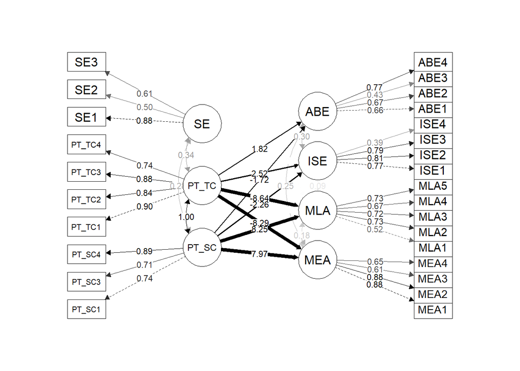

```r
# Path diagram using semPlot
if (!requireNamespace("semPlot", quietly = TRUE)) install.packages("semPlot")
library(semPlot)

semPaths(sem_fit,
         what = "std",
         whatLabels = "std",
         layout = "tree",
         rotation = 2,
         nCharNodes = 0,
         sizeMan = 8,
         sizeMan2 = 4,
         edge.label.cex = 0.8,
         edge.color = "black",
         title = FALSE,
         intercepts = FALSE,
         residuals = FALSE,
         thresholds = FALSE)
```

```r
# Save figure
pdf("Figure2_Structural_Model.pdf", width = 12, height = 8)
semPaths(sem_fit,
         what = "std",
         whatLabels = "std",
         layout = "tree",
         rotation = 2,
         nCharNodes = 0,
         sizeMan = 8,
         sizeMan2 = 4,
         edge.label.cex = 0.8,
         edge.color = "black",
         title = FALSE,
         intercepts = FALSE,
         residuals = FALSE,
         thresholds = FALSE)
dev.off()
```

**FIGURE 3: Interaction Plot (Self-Efficacy Moderation)**

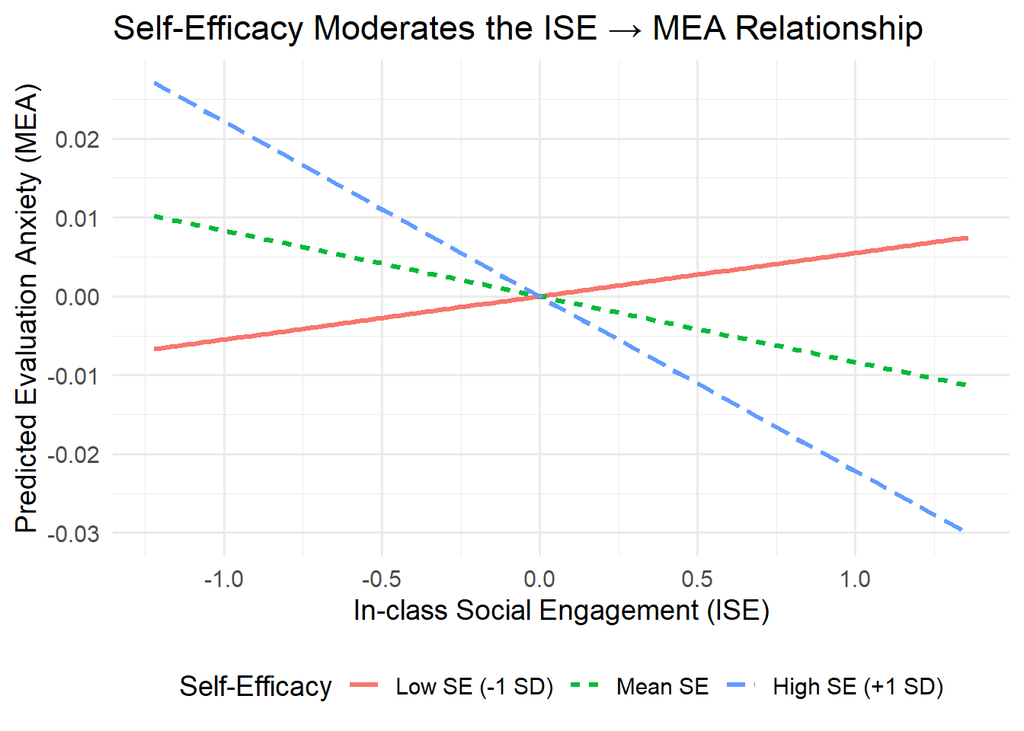

```r
# Create interaction plot
interaction_data <- expand.grid(
  ISE = seq(min(data$ISE, na.rm = TRUE),
            max(data$ISE, na.rm = TRUE),
            length.out = 100),
  SE = c(-1, 0, 1)
)

interaction_data$SE_label <- factor(interaction_data$SE,
                                     levels = c(-1, 0, 1),
                                     labels = c("Low SE (-1 SD)",
                                                "Mean SE",
                                                "High SE (+1 SD)"))

# Predicted MEA values
b1 <- coef(mod_fit)["b1"]
mod1 <- coef(mod_fit)["mod1"]
interaction_data$MEA_pred <- b1 * interaction_data$ISE +
                             mod1 * interaction_data$ISE * interaction_data$SE

# Plot
interaction_plot <- ggplot(interaction_data,
                           aes(x = ISE, y = MEA_pred,
                               color = SE_label, linetype = SE_label)) +
  geom_line(size = 1.2) +
  labs(
    x = "In-class Social Engagement (ISE)",
    y = "Predicted Evaluation Anxiety (MEA)",
    color = "Self-Efficacy",
    linetype = "Self-Efficacy",
    title = "Self-Efficacy Moderates the ISE → MEA Relationship"
  ) +
  theme_minimal(base_size = 14) +
  theme(legend.position = "bottom")

print(interaction_plot)
```

```r
#ggsave("Figure3_Interaction_Plot.pdf", interaction_plot,
#       width = 8, height = 6, dpi = 300)
```

This figure visualizes the moderating effect of Self-Efficacy (SE) on the relationship between In-class Social Engagement (ISE) and Predicted Evaluation Anxiety (MEA). The three lines represent the ISE → MEA slope at three levels of SE: low (−1 SD), mean, and high (+1 SD).

```r
# ----------------------------------------------------------------------------
# 7. ADDITIONAL ANALYSES
# ----------------------------------------------------------------------------

# --- Multigroup Analysis by Gender ---
# Test measurement invariance
configural <- lavaan::cfa(measurement_model, data = data, group = "gender")
metric <- lavaan::cfa(measurement_model, data = data, group = "gender",
                       group.equal = "loadings")
scalar <- lavaan::cfa(measurement_model, data = data, group = "gender",
                       group.equal = c("loadings", "intercepts"))

invariance_table <- data.frame(
  Model = c("Configural", "Metric", "Scalar"),
  CFI = c(round(fitMeasures(configural, "cfi"), 3),
          round(fitMeasures(metric, "cfi"), 3),
          round(fitMeasures(scalar, "cfi"), 3)),
  RMSEA = c(round(fitMeasures(configural, "rmsea"), 3),
            round(fitMeasures(metric, "rmsea"), 3),
            round(fitMeasures(scalar, "rmsea"), 3)),
  SRMR = c(round(fitMeasures(configural, "srmr"), 3),
           round(fitMeasures(metric, "srmr"), 3),
           round(fitMeasures(scalar, "srmr"), 3)),
  dCFI = c(NA,
           round(fitMeasures(metric, "cfi") - fitMeasures(configural, "cfi"), 3),
           round(fitMeasures(scalar, "cfi") - fitMeasures(metric, "cfi"), 3)),
  dRMSEA = c(NA,
             round(fitMeasures(metric, "rmsea") - fitMeasures(configural, "rmsea"), 3),
             round(fitMeasures(scalar, "rmsea") - fitMeasures(metric, "rmsea"), 3))
)

print(invariance_table)
```

```
       Model   CFI RMSEA  SRMR   dCFI dRMSEA
1 Configural 0.919 0.059 0.053     NA     NA
2     Metric 0.916 0.060 0.057 -0.003  0.000
3     Scalar 0.910 0.061 0.058 -0.006  0.001
```

```r
#write.csv(invariance_table, "Table_Measurement_Invariance.csv", row.names = FALSE)
```

```r
# --- Multigroup Analysis by Course Level ---
configural_course <- lavaan::cfa(measurement_model, data = data,
                                  group = "course_level")
metric_course <- lavaan::cfa(measurement_model, data = data,
                              group = "course_level",
                              group.equal = "loadings")

course_invariance <- data.frame(
  Model = c("Configural", "Metric"),
  CFI = c(round(fitMeasures(configural_course, "cfi"), 3),
          round(fitMeasures(metric_course, "cfi"), 3)),
  RMSEA = c(round(fitMeasures(configural_course, "rmsea"), 3),
            round(fitMeasures(metric_course, "rmsea"), 3)),
  SRMR = c(round(fitMeasures(configural_course, "srmr"), 3),
           round(fitMeasures(metric_course, "srmr"), 3))
)

print(course_invariance)
```

```
       Model   CFI RMSEA  SRMR
1 Configural 0.888 0.072 0.076
2     Metric 0.883 0.071 0.083
```

```r
#write.csv(course_invariance, "Table_Course_Invariance.csv", row.names = FALSE)
```

**8. POWER ANALYSIS (POST HOC)**

The function computes the probability of correctly rejecting the null hypothesis (that the model fits perfectly in the population) given your sample size, model df, and the assumed population RMSEA of 0.05.

```r
# Post hoc power for SEM
library(semPower)
##
power_result <- semPower.postHoc(
  effect = 0.05,
  effect.measure = "RMSEA",
  alpha = 0.05,
  N = n,
  df = fitMeasures(sem_fit, "df")
)
summary(power_result)

print(power_result)
```

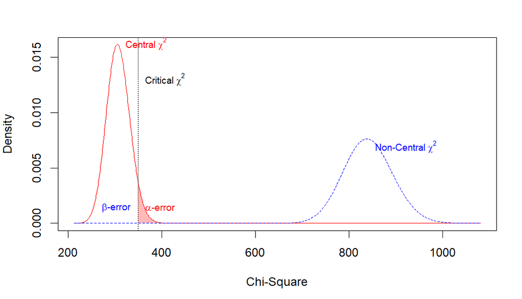

```r
include_graphics("Goodness-of-fit-SEM.png")
```

The figure shows your SEM has very high post hoc power (near 1.0) to detect an RMSEA of 0.05, with a negligible Type II error rate and a controlled 5% Type I error rate. Visually, the non-central χ² distribution sits almost entirely to the right of the critical value, indicating strong separation between the null and alternative hypotheses. However, interpret this cautiously — post hoc power is a restatement of the original test result rather than independent evidence of study adequacy.

```r
# ----------------------------------------------------------------------------
# 9. EXPORT ALL TABLES TO A SINGLE EXCEL FILE
# ----------------------------------------------------------------------------

if (!requireNamespace("openxlsx", quietly = TRUE)) install.packages("openxlsx")
library(openxlsx)

# Create workbook
wb <- createWorkbook()

# Add sheets
addWorksheet(wb, "Table1_Instruments")
addWorksheet(wb, "Table2_Descriptives")
addWorksheet(wb, "Table2_Correlations")
addWorksheet(wb, "Table2_Reliability")
addWorksheet(wb, "Table3_Structural_Paths")
addWorksheet(wb, "Table4_Indirect_Effects")
addWorksheet(wb, "Table_SEM_Fit")
addWorksheet(wb, "Table_CFA_Loadings")
addWorksheet(wb, "Table_Moderation")
addWorksheet(wb, "Table_Simple_Slopes")
addWorksheet(wb, "Table_Measurement_Invariance")
addWorksheet(wb, "Table_Course_Invariance")

# Write data to sheets
writeData(wb, "Table2_Descriptives", desc_stats)
writeData(wb, "Table2_Correlations", as.data.frame(cor_table))
writeData(wb, "Table2_Reliability", rel_table)
writeData(wb, "Table3_Structural_Paths", path_coefs)
writeData(wb, "Table4_Indirect_Effects", indirect_effects)
writeData(wb, "Table_SEM_Fit", sem_fit_indices)
writeData(wb, "Table_CFA_Loadings", loadings)
writeData(wb, "Table_Moderation", moderation_results)
writeData(wb, "Table_Simple_Slopes", simple_slopes)
writeData(wb, "Table_Measurement_Invariance", invariance_table)
writeData(wb, "Table_Course_Invariance", course_invariance)

# Save workbook
saveWorkbook(wb, "All_Tables_Output.xlsx", overwrite = TRUE)

# ----------------------------------------------------------------------------
# 10. SESSION INFORMATION
# ----------------------------------------------------------------------------

sessionInfo()
```